# The PISA Data

## Introduction

> In this first part, I will conduct an exploratory data analysis on a dataset of my choice. I will then use Python data science and data visualization libraries to explore the dataset’s variables and understand the data’s structure, oddities, patterns, and relationships.

> The dataset that I chose to explore was the PISA 2012 assessment.

> PISA Data: PISA is a survey of students' skills and knowledge as they approach the end of compulsory education. This survey examines
> - how well students have learned the school curriculum,
> - how well prepared they are for life beyond school.

> PISA is a unique global survey that examines how well prepared 15 year old students are for life after they have completed school. Around 510,000 students in 65 economies took part in the PISA 2012 assessment of reading, mathematics and science. Of those economies, 44 took part in an assessment of creative problem solving and 18 in an assessment of financial literacy.

## Preliminary Wrangling

```python
# These are the libraries that I will use for the project.
import pandas as pd
import numpy as np
import matplotlib.pyplot as mplt
import zipfile
import seaborn as sb

# This will make the plots to be embedded inline.
%matplotlib inline
```

## Gathering The Data

```python
# Now I will load my dataset so I can begin my exploration.
pisa_data = pd.read_csv('C:/Users/Lauren.Mukanda/Downloads/pisa2012.csv.zip', encoding='latin-1', compression= 'zip',
                        usecols = ['CNT','ST03Q02','ST04Q01','ST15Q01','ST19Q01',
                                   'PV1MATH','PV2MATH','PV3MATH','PV4MATH','PV5MATH',
                                   'PV1READ','PV2READ','PV3READ','PV4READ','PV5READ',
                                   'PV1SCIE','PV2SCIE','PV3SCIE','PV4SCIE','PV5SCIE'])
```

### What is/are the main feature(s) of interest in your dataset?

> - I want to take a look at what factors have an effect on the overall scores in Maths **(PV1MATH , PV2MATH, PV3MATH, PV4MATH, PV5MATH)**, Reading **(PV1READ, PV2READ, PV3READ, PV4READ, PV5READ)**, and Science **(PV1SCIE, PV2SCIE, PV3SCIE, PV4SCIE, PV5SCIE)** of the students that participate in these tests.

### What features in the dataset do you think will help support your investigation into your feature(s) of interest?

> - There are indeed a lot of factors that would play a role in this, but I will only be taking a look at whether gender **(ST04Q01)** or birth year **(ST03Q02)** plays a role, or if the country **(CNT)** where the test is taken contributes as well and I will also look at if the parents job status **(ST15Q01 and ST19Q01)** plays a role.

## Assessing The Data

> In this section, detect and document quality issues and tidiness issue. You must use both visual assessment and programmatic assessement to assess the data.

```python
# This allows you to see how many rows and columns are located in your dataset.
pisa_data.shape
```

```
(485490, 20)
```

```python
# Print out the first 5 observation so you can see your dataset.
pisa_data.head()
```

|  | CNT | ST03Q02 | ST04Q01 | ST15Q01 | ST19Q01 | PV1MATH | PV2MATH | PV3MATH | PV4MATH | PV5MATH | PV1READ | PV2READ | PV3READ | PV4READ | PV5READ | PV1SCIE | PV2SCIE | PV3SCIE | PV4SCIE | PV5SCIE |
| --- | --- | --- | --- | --- | --- | --- | --- | --- | --- | --- | --- | --- | --- | --- | --- | --- | --- | --- | --- | --- |
| 0 | Albania | 1996 | Female | Other (e.g. home duties, retired) | Working part-time <for pay> | 406.8469 | 376.4683 | 344.5319 | 321.1637 | 381.9209 | 249.5762 | 254.3420 | 406.8496 | 175.7053 | 218.5981 | 341.7009 | 408.8400 | 348.2283 | 367.8105 | 392.9877 |
| 1 | Albania | 1996 | Female | Working full-time <for pay> | Working full-time <for pay> | 486.1427 | 464.3325 | 453.4273 | 472.9008 | 476.0165 | 406.2936 | 349.8975 | 400.7334 | 369.7553 | 396.7618 | 548.9929 | 471.5964 | 471.5964 | 443.6218 | 454.8116 |
| 2 | Albania | 1996 | Female | Working full-time <for pay> | Working full-time <for pay> | 533.2684 | 481.0796 | 489.6479 | 490.4269 | 533.2684 | 401.2100 | 404.3872 | 387.7067 | 431.3938 | 401.2100 | 499.6643 | 428.7952 | 492.2044 | 512.7191 | 499.6643 |
| 3 | Albania | 1996 | Female | Working full-time <for pay> | Working full-time <for pay> | 412.2215 | 498.6836 | 415.3373 | 466.7472 | 454.2842 | 547.3630 | 481.4353 | 461.5776 | 425.0393 | 471.9036 | 438.6796 | 481.5740 | 448.9370 | 474.1141 | 426.5573 |
| 4 | Albania | 1996 | Female | Working part-time <for pay> | Working part-time <for pay> | 381.9209 | 328.1742 | 403.7311 | 418.5309 | 395.1628 | 311.7707 | 141.7883 | 293.5015 | 272.8495 | 260.1405 | 361.5628 | 275.7740 | 372.7527 | 403.5248 | 422.1746 |

```python
# This will print out the full information of your DataFrame
pisa_data.info()
```

```
<class 'pandas.core.frame.DataFrame'>
RangeIndex: 485490 entries, 0 to 485489
Data columns (total 20 columns):
 #   Column   Non-Null Count   Dtype
---  ------   --------------   -----
 0   CNT      485490 non-null  object
 1   ST03Q02  485490 non-null  int64
 2   ST04Q01  485490 non-null  object
 3   ST15Q01  467751 non-null  object
 4   ST19Q01  451410 non-null  object
 5   PV1MATH  485490 non-null  float64
 6   PV2MATH  485490 non-null  float64
 7   PV3MATH  485490 non-null  float64
 8   PV4MATH  485490 non-null  float64
 9   PV5MATH  485490 non-null  float64
 10  PV1READ  485490 non-null  float64
 11  PV2READ  485490 non-null  float64
 12  PV3READ  485490 non-null  float64
 13  PV4READ  485490 non-null  float64
 14  PV5READ  485490 non-null  float64
 15  PV1SCIE  485490 non-null  float64
 16  PV2SCIE  485490 non-null  float64
 17  PV3SCIE  485490 non-null  float64
 18  PV4SCIE  485490 non-null  float64
 19  PV5SCIE  485490 non-null  float64
dtypes: float64(15), int64(1), object(4)
memory usage: 74.1+ MB
```

```python
# This is just to check if we have any duplicated observation on our DataFrame
sum(pisa_data.duplicated())
```

```
0
```

```python
# This will just give us the statistic of our DataFrame
pisa_data.describe()
```

|  | ST03Q02 | PV1MATH | PV2MATH | PV3MATH | PV4MATH | PV5MATH | PV1READ | PV2READ | PV3READ | PV4READ | PV5READ | PV1SCIE | PV2SCIE | PV3SCIE | PV4SCIE | PV5SCIE |
| --- | --- | --- | --- | --- | --- | --- | --- | --- | --- | --- | --- | --- | --- | --- | --- | --- |
| count | 485490.000000 | 485490.000000 | 485490.000000 | 485490.000000 | 485490.000000 | 485490.000000 | 485490.000000 | 485490.000000 | 485490.000000 | 485490.000000 | 485490.000000 | 485490.000000 | 485490.000000 | 485490.000000 | 485490.00000 | 485490.000000 |
| mean | 1996.070061 | 469.621653 | 469.648358 | 469.648930 | 469.641832 | 469.695396 | 472.004640 | 472.068052 | 472.022059 | 471.926562 | 472.013506 | 475.769824 | 475.813674 | 475.851549 | 475.78524 | 475.820184 |
| std | 0.255250 | 103.265391 | 103.382077 | 103.407631 | 103.392286 | 103.419170 | 102.505523 | 102.626198 | 102.640489 | 102.576066 | 102.659989 | 101.464426 | 101.514649 | 101.495072 | 101.51220 | 101.566347 |
| min | 1996.000000 | 19.792800 | 6.473000 | 42.226200 | 24.622200 | 37.085200 | 0.083400 | 0.703500 | 0.703500 | 4.134400 | 2.307400 | 2.648300 | 2.834800 | 11.879900 | 8.42970 | 17.754600 |
| 25% | 1996.000000 | 395.318600 | 395.318600 | 395.240700 | 395.396500 | 395.240700 | 403.600700 | 403.360100 | 403.360100 | 403.354600 | 403.360100 | 404.457300 | 404.457300 | 404.550500 | 404.45730 | 404.457300 |
| 50% | 1996.000000 | 466.201900 | 466.124000 | 466.201900 | 466.279800 | 466.435600 | 475.455000 | 475.535200 | 475.455000 | 475.535200 | 475.535200 | 475.699400 | 475.606100 | 475.699400 | 475.97910 | 475.885900 |
| 75% | 1996.000000 | 541.057800 | 541.447300 | 541.291500 | 541.447300 | 541.447300 | 544.502500 | 544.503500 | 544.503500 | 544.502500 | 544.503500 | 547.780700 | 547.873900 | 547.967200 | 547.78070 | 547.780700 |
| max | 1997.000000 | 962.229300 | 957.010400 | 935.745400 | 943.456900 | 907.625800 | 904.802600 | 881.239200 | 884.447000 | 881.159000 | 901.608600 | 903.338300 | 900.540800 | 867.624000 | 926.55730 | 880.958600 |

## Cleaning The Data

> Clean all of the issues you documented while assessing. Perform this cleaning in the "Cleaning Data" section.

```python
# Before I clean my dataset I first want to make a copy so that way I can preserve the original data.
pisa_data_clean = pisa_data.copy()
```

```python
# First I want to create columns for the average scores of maths, science and reading
pisa_data_clean['Math Score Average'] = (pisa_data_clean['PV1MATH'] + pisa_data_clean['PV2MATH'] + pisa_data_clean['PV3MATH'] + pisa_data_clean['PV4MATH'] + pisa_data_clean['PV5MATH']) / 5
pisa_data_clean['Reading Score Average'] = (pisa_data_clean['PV1READ'] + pisa_data_clean['PV2READ'] + pisa_data_clean['PV3READ'] + pisa_data_clean['PV4READ'] + pisa_data_clean['PV5READ']) / 5
pisa_data_clean['Science Score Average'] = (pisa_data_clean['PV1SCIE'] + pisa_data_clean['PV2SCIE'] + pisa_data_clean['PV3SCIE'] + pisa_data_clean['PV4SCIE'] + pisa_data_clean['PV5SCIE']) / 5

# Second I want to create a coloumn for the maximum scores of maths, reading and science
pisa_data_clean['Maximum Math Score'] = pisa_data_clean[['PV1MATH','PV2MATH', 'PV3MATH', 'PV4MATH', 'PV5MATH']].max(axis=1)
pisa_data_clean['Maximum Reading Score'] = pisa_data_clean[['PV1READ', 'PV2READ', 'PV3READ', 'PV4READ', 'PV5READ']].max(axis=1)
pisa_data_clean['Maximum Science Score'] = pisa_data_clean[['PV1SCIE', 'PV2SCIE', 'PV3SCIE', 'PV4SCIE', 'PV5SCIE']].max(axis=1)
```

```python
# Then I drop those columns used for the average scores because they are not needed anymore
pisa_data_clean.drop(columns=['PV1MATH', 'PV2MATH', 'PV3MATH', 'PV4MATH', 'PV5MATH', 'PV1READ', 'PV2READ', 'PV3READ', 'PV4READ',
                 'PV5READ', 'PV1SCIE', 'PV2SCIE', 'PV3SCIE', 'PV4SCIE', 'PV5SCIE'], inplace=True)
```

```python
#This is to make sure that the changes I made are implemented
pisa_data_clean.info()
```

```
<class 'pandas.core.frame.DataFrame'>
RangeIndex: 485490 entries, 0 to 485489
Data columns (total 11 columns):
 #   Column                 Non-Null Count   Dtype
---  ------                 --------------   -----
 0   CNT                    485490 non-null  object
 1   ST03Q02                485490 non-null  int64
 2   ST04Q01                485490 non-null  object
 3   ST15Q01                467751 non-null  object
 4   ST19Q01                451410 non-null  object
 5   Math Score Average     485490 non-null  float64
 6   Reading Score Average  485490 non-null  float64
 7   Science Score Average  485490 non-null  float64
 8   Maximum Math Score     485490 non-null  float64
 9   Maximum Reading Score  485490 non-null  float64
 10  Maximum Science Score  485490 non-null  float64
dtypes: float64(6), int64(1), object(4)
memory usage: 40.7+ MB
```

```python
pisa_data_clean.head()
```

|  | CNT | ST03Q02 | ST04Q01 | ST15Q01 | ST19Q01 | Math Score Average | Reading Score Average | Science Score Average | Maximum Math Score | Maximum Reading Score | Maximum Science Score |
| --- | --- | --- | --- | --- | --- | --- | --- | --- | --- | --- | --- |
| 0 | Albania | 1996 | Female | Other (e.g. home duties, retired) | Working part-time <for pay> | 366.18634 | 261.01424 | 371.91348 | 406.8469 | 406.8496 | 408.8400 |
| 1 | Albania | 1996 | Female | Working full-time <for pay> | Working full-time <for pay> | 470.56396 | 384.68832 | 478.12382 | 486.1427 | 406.2936 | 548.9929 |
| 2 | Albania | 1996 | Female | Working full-time <for pay> | Working full-time <for pay> | 505.53824 | 405.18154 | 486.60946 | 533.2684 | 431.3938 | 512.7191 |
| 3 | Albania | 1996 | Female | Working full-time <for pay> | Working full-time <for pay> | 449.45476 | 477.46376 | 453.97240 | 498.6836 | 547.3630 | 481.5740 |
| 4 | Albania | 1996 | Female | Working part-time <for pay> | Working part-time <for pay> | 385.50398 | 256.01010 | 367.15778 | 418.5309 | 311.7707 | 422.1746 |

```python
# This will get us the summary of the mothers job status
pisa_data_clean['ST15Q01'].describe()
```

```
count                           467751
unique                               4
top       Working full-time <for pay>
freq                            219095
Name: ST15Q01, dtype: object
```

```python
# This is just so that we can view the unique values in the mothers job status
pisa_data_clean['ST15Q01'].unique()
```

```
array(['Other (e.g. home duties, retired) ',
       'Working full-time <for pay> ', 'Working part-time <for pay>',
       'Not working, but looking for a job ', nan], dtype=object)
```

```python
# This will create a dictionary that will represent all the unique values into numbers for easy analysis
mom_work_dict = {
    "Working full-time <for pay> " : "1",
    "Other (e.g. home duties, retired) " : "2",
    "Working part-time <for pay>" : "3",
    "Not working, but looking for a job " : "4",
    np.nan:"0"
}


# After creating the dictionary we want to create a column that has the rplaced values
mom_work = pisa_data_clean['ST15Q01'].replace(mom_work_dict);
```

```python
pisa_data_clean = pisa_data_clean.assign(mom_work = pisa_data_clean['ST15Q01'].replace(mom_work_dict))
```

```python
# This will get us the summary of the fathers job status
pisa_data_clean['ST19Q01'].describe()
```

```
count                           451410
unique                               4
top       Working full-time <for pay>
freq                            339697
Name: ST19Q01, dtype: object
```

```python
# This is just so that we can view the unique values in the fathers job status
pisa_data_clean['ST19Q01'].unique()
```

```
array(['Working part-time <for pay>', 'Working full-time <for pay> ',
       'Not working, but looking for a job',
       'Other (e.g. home duties, retired) ', nan], dtype=object)
```

```python
# This will create a dictionary that will represent all the unique values into numbers for easy analysis
dad_work_dict = {
    "Working full-time <for pay> " : "1",
    "Other (e.g. home duties, retired) " : "2",
    "Working part-time <for pay>" : "3",
    "Not working, but looking for a job " : "4",
    np.nan:"0"
}


# After creating the dictionary we want to create a column that has the rplaced values
dad_work = pisa_data_clean['ST19Q01'].replace(dad_work_dict);
```

```python
pisa_data_clean = pisa_data_clean.assign(dad_work = pisa_data_clean['ST19Q01'].replace(dad_work_dict))
```

```python
# Before continuing we just need to make sure that what we did was implemented correctly
pisa_data_clean.head()
```

|  | CNT | ST03Q02 | ST04Q01 | ST15Q01 | ST19Q01 | Math Score Average | Reading Score Average | Science Score Average | Maximum Math Score | Maximum Reading Score | Maximum Science Score | mom_work | dad_work |
| --- | --- | --- | --- | --- | --- | --- | --- | --- | --- | --- | --- | --- | --- |
| 0 | Albania | 1996 | Female | Other (e.g. home duties, retired) | Working part-time <for pay> | 366.18634 | 261.01424 | 371.91348 | 406.8469 | 406.8496 | 408.8400 | 2 | 3 |
| 1 | Albania | 1996 | Female | Working full-time <for pay> | Working full-time <for pay> | 470.56396 | 384.68832 | 478.12382 | 486.1427 | 406.2936 | 548.9929 | 1 | 1 |
| 2 | Albania | 1996 | Female | Working full-time <for pay> | Working full-time <for pay> | 505.53824 | 405.18154 | 486.60946 | 533.2684 | 431.3938 | 512.7191 | 1 | 1 |
| 3 | Albania | 1996 | Female | Working full-time <for pay> | Working full-time <for pay> | 449.45476 | 477.46376 | 453.97240 | 498.6836 | 547.3630 | 481.5740 | 1 | 1 |
| 4 | Albania | 1996 | Female | Working part-time <for pay> | Working part-time <for pay> | 385.50398 | 256.01010 | 367.15778 | 418.5309 | 311.7707 | 422.1746 | 3 | 3 |

```python
pisa_data_clean.info()
```

```
<class 'pandas.core.frame.DataFrame'>
RangeIndex: 485490 entries, 0 to 485489
Data columns (total 13 columns):
 #   Column                 Non-Null Count   Dtype
---  ------                 --------------   -----
 0   CNT                    485490 non-null  object
 1   ST03Q02                485490 non-null  int64
 2   ST04Q01                485490 non-null  object
 3   ST15Q01                467751 non-null  object
 4   ST19Q01                451410 non-null  object
 5   Math Score Average     485490 non-null  float64
 6   Reading Score Average  485490 non-null  float64
 7   Science Score Average  485490 non-null  float64
 8   Maximum Math Score     485490 non-null  float64
 9   Maximum Reading Score  485490 non-null  float64
 10  Maximum Science Score  485490 non-null  float64
 11  mom_work               485490 non-null  object
 12  dad_work               485490 non-null  object
dtypes: float64(6), int64(1), object(6)
memory usage: 48.2+ MB
```

```python
# This will create a function that allows us to combine the observation of the mothers and fathers job status as one
# observation for the household.
def work_status(mom_work,dad_work):
    """
    This function will rename the parents job status to make it more understandable
    """
# Other stands for e.g. home duties, retired

    if mom_work == '2' and dad_work == '2':
        status = 'Both other'
    elif mom_work == '2' and dad_work == '0':
        status = 'only mom other'
    elif mom_work == '0' and dad_work == '2':
        status = 'Only dad other'
    elif mom_work == '4' and dad_work == '4':
        status = 'Both looking for work'
 #Both Parents are working
    elif (mom_work == '1' and dad_work == '1') or (mom_work == '1' and dad_work == '3'):
        status = 'Both working'
    elif (mom_work == '3' and dad_work == '3') or (mom_work == '3' and dad_work == '1'):
        status = 'Both working'
# Only mom is working
    elif (mom_work == '1' and dad_work == '0') or (mom_work == '3' and dad_work == '0'):
        status = 'Only mom working'
    elif (mom_work == '1' and dad_work == '2') or (mom_work == '3' and dad_work == '2'):
        status = 'Only mom working'
    elif (mom_work == '1' and dad_work == '4') or (mom_work == '3' and dad_work == '4'):
        status = 'Only mom working'
# Only dad is working
    elif (mom_work == '0' and dad_work == '1') or (mom_work == '0' and dad_work == '3'):
        status = 'Only dad working'
    elif (mom_work == '2' and dad_work == '1') or (mom_work == '2' and dad_work == '3'):
        status = 'Only dad working'
    elif (mom_work == '4' and dad_work == '1') or (mom_work == '4' and dad_work == '3'):
        status = 'Only dad working'
# only one parent is looking for work
    elif (mom_work == '4' and dad_work == '0') or (mom_work == '4' and dad_work == '2'):
        status = 'Only mom looking for work'
    elif (mom_work == '0' and dad_work == '4') or (mom_work == '2' and dad_work == '4'):
        status = 'Only dad looking for work'
    else:
        status = 'Unknown'
    return status
```

```python
# This code will create a new column where our function will be applied
pisa_data_clean["parents_job_status"] = pisa_data_clean.apply(lambda x: work_status(x["mom_work"],x["dad_work"]), axis=1)
```

```python
# this code will just show us the value counts of the parents job status
pisa_data_clean["parents_job_status"].value_counts()
```

```
Both working                 255293
Only dad working             133907
Unknown                       31086
Only mom working              30996
Both other                    22388
only mom other                 6563
Only mom looking for work      4452
Only dad other                  805
Name: parents_job_status, dtype: int64
```

```python
# this is to just make sure that what we did above has been correctly implemented
pisa_data_clean.head()
```

|  | CNT | ST03Q02 | ST04Q01 | ST15Q01 | ST19Q01 | Math Score Average | Reading Score Average | Science Score Average | Maximum Math Score | Maximum Reading Score | Maximum Science Score | mom_work | dad_work | parents_job_status |
| --- | --- | --- | --- | --- | --- | --- | --- | --- | --- | --- | --- | --- | --- | --- |
| 0 | Albania | 1996 | Female | Other (e.g. home duties, retired) | Working part-time <for pay> | 366.18634 | 261.01424 | 371.91348 | 406.8469 | 406.8496 | 408.8400 | 2 | 3 | Only dad working |
| 1 | Albania | 1996 | Female | Working full-time <for pay> | Working full-time <for pay> | 470.56396 | 384.68832 | 478.12382 | 486.1427 | 406.2936 | 548.9929 | 1 | 1 | Both working |
| 2 | Albania | 1996 | Female | Working full-time <for pay> | Working full-time <for pay> | 505.53824 | 405.18154 | 486.60946 | 533.2684 | 431.3938 | 512.7191 | 1 | 1 | Both working |
| 3 | Albania | 1996 | Female | Working full-time <for pay> | Working full-time <for pay> | 449.45476 | 477.46376 | 453.97240 | 498.6836 | 547.3630 | 481.5740 | 1 | 1 | Both working |
| 4 | Albania | 1996 | Female | Working part-time <for pay> | Working part-time <for pay> | 385.50398 | 256.01010 | 367.15778 | 418.5309 | 311.7707 | 422.1746 | 3 | 3 | Both working |

```python
# I will drop those columns that are not needed anymore
pisa_data_clean.drop(columns=['ST15Q01', 'ST19Q01'], inplace=True)
```

```python
# Before continuing we just need to make sure that what we did was implemented correctly
pisa_data_clean.head()
```

|  | CNT | ST03Q02 | ST04Q01 | Math Score Average | Reading Score Average | Science Score Average | Maximum Math Score | Maximum Reading Score | Maximum Science Score | mom_work | dad_work | parents_job_status |
| --- | --- | --- | --- | --- | --- | --- | --- | --- | --- | --- | --- | --- |
| 0 | Albania | 1996 | Female | 366.18634 | 261.01424 | 371.91348 | 406.8469 | 406.8496 | 408.8400 | 2 | 3 | Only dad working |
| 1 | Albania | 1996 | Female | 470.56396 | 384.68832 | 478.12382 | 486.1427 | 406.2936 | 548.9929 | 1 | 1 | Both working |
| 2 | Albania | 1996 | Female | 505.53824 | 405.18154 | 486.60946 | 533.2684 | 431.3938 | 512.7191 | 1 | 1 | Both working |
| 3 | Albania | 1996 | Female | 449.45476 | 477.46376 | 453.97240 | 498.6836 | 547.3630 | 481.5740 | 1 | 1 | Both working |
| 4 | Albania | 1996 | Female | 385.50398 | 256.01010 | 367.15778 | 418.5309 | 311.7707 | 422.1746 | 3 | 3 | Both working |

```python
# This code is so that we can see the unique values in the CNT column so that we can see if any thing needs to be renamed
pisa_data_clean['CNT'].unique()
```

```
array(['Albania', 'United Arab Emirates', 'Argentina', 'Australia',
       'Austria', 'Belgium', 'Bulgaria', 'Brazil', 'Canada',
       'Switzerland', 'Chile', 'Colombia', 'Costa Rica', 'Czech Republic',
       'Germany', 'Denmark', 'Spain', 'Estonia', 'Finland', 'France',
       'United Kingdom', 'Greece', 'Hong Kong-China', 'Croatia',
       'Hungary', 'Indonesia', 'Ireland', 'Iceland', 'Israel', 'Italy',
       'Jordan', 'Japan', 'Kazakhstan', 'Korea', 'Liechtenstein',
       'Lithuania', 'Luxembourg', 'Latvia', 'Macao-China', 'Mexico',
       'Montenegro', 'Malaysia', 'Netherlands', 'Norway', 'New Zealand',
       'Peru', 'Poland', 'Portugal', 'Qatar', 'China-Shanghai',
       'Perm(Russian Federation)', 'Florida (USA)', 'Connecticut (USA)',
       'Massachusetts (USA)', 'Romania', 'Russian Federation',
       'Singapore', 'Serbia', 'Slovak Republic', 'Slovenia', 'Sweden',
       'Chinese Taipei', 'Thailand', 'Tunisia', 'Turkey', 'Uruguay',
       'United States of America', 'Vietnam'], dtype=object)
```

```python
# As we can see that some states are listed as countriess so here i just want to make sure that countries are not duplicated
# and that they all identified as the countries they are.
pisa_data_clean.loc[pisa_data_clean['CNT'] == 'Florida (USA)', 'CNT'] = 'USA'
pisa_data_clean.loc[pisa_data_clean['CNT'] == 'Connecticut (USA)', 'CNT'] = 'USA'
pisa_data_clean.loc[pisa_data_clean['CNT'] == 'Massachusetts (USA)', 'CNT'] = 'USA'
pisa_data_clean.loc[pisa_data_clean['CNT'] == 'United States of America', 'CNT'] = 'USA'
pisa_data_clean.loc[pisa_data_clean['CNT'] == 'Russian Federation', 'CNT'] = 'Russia'
pisa_data_clean.loc[pisa_data_clean['CNT'] == 'Chinese Taipei', 'CNT'] = 'Taiwan'

# Because Hong Kong and Macao are special administrative regions that are not included
# in the statistics of the Peoples's Republic of China I will keep them as they are.
```

```python
#This is to make sure that the changes I made are implemented
pisa_data_clean['CNT'].value_counts()
```

```
Mexico                      33806
Italy                       31073
Spain                       25313
Canada                      21544
Brazil                      19204
                            ...
Latvia                       4306
New Zealand                  4291
Iceland                      3508
Perm(Russian Federation)     1761
Liechtenstein                 293
Name: CNT, Length: 65, dtype: int64
```

```python
# Now that i'm done with my cleaning I want change the names of the columns to make it more easy to identify
pisa_data_clean.rename({'CNT':'Country Code',
                        'ST03Q02':'Birth Year',
                        'ST04Q01':'Gender',
                        'mom_work':'Mom Work Status',
                        'dad_work':'Dad Work Status',
                        'parents_job_status': 'Parents Work Status'},
                       axis = 'columns', inplace=True)
```

```python
pisa_data_clean.info()
```

```
<class 'pandas.core.frame.DataFrame'>
RangeIndex: 485490 entries, 0 to 485489
Data columns (total 12 columns):
 #   Column                 Non-Null Count   Dtype
---  ------                 --------------   -----
 0   Country Code           485490 non-null  object
 1   Birth Year             485490 non-null  int64
 2   Gender                 485490 non-null  object
 3   Math Score Average     485490 non-null  float64
 4   Reading Score Average  485490 non-null  float64
 5   Science Score Average  485490 non-null  float64
 6   Maximum Math Score     485490 non-null  float64
 7   Maximum Reading Score  485490 non-null  float64
 8   Maximum Science Score  485490 non-null  float64
 9   Mom Work Status        485490 non-null  object
 10  Dad Work Status        485490 non-null  object
 11  Parents Work Status    485490 non-null  object
dtypes: float64(6), int64(1), object(5)
memory usage: 44.4+ MB
```

## Storing Data

> In the "Storing Data" section, store the cleaned modified DataFrame in a CSV file, so that you can use that for your analysis.

```python
# Now that my data is cleaned I will save it as a modified dataset and work with that to do my analysis
pisa_data_clean.to_csv('C:/Users/Lauren.Mukanda/Downloads/modified_pisa_data.csv', index=False)
```

```python
# Now that we've cleaned our master data and saved it as a .csv file
# now we want to open so that we can analyze and visualize it.
modified_pisa_data = pd.read_csv('C:/Users/Lauren.Mukanda/Downloads/modified_pisa_data.csv', low_memory=False)
modified_pisa_data.info()
```

```
<class 'pandas.core.frame.DataFrame'>
RangeIndex: 485490 entries, 0 to 485489
Data columns (total 12 columns):
 #   Column                 Non-Null Count   Dtype
---  ------                 --------------   -----
 0   Country Code           485490 non-null  object
 1   Birth Year             485490 non-null  int64
 2   Gender                 485490 non-null  object
 3   Math Score Average     485490 non-null  float64
 4   Reading Score Average  485490 non-null  float64
 5   Science Score Average  485490 non-null  float64
 6   Maximum Math Score     485490 non-null  float64
 7   Maximum Reading Score  485490 non-null  float64
 8   Maximum Science Score  485490 non-null  float64
 9   Mom Work Status        485490 non-null  int64
 10  Dad Work Status        485490 non-null  object
 11  Parents Work Status    485490 non-null  object
dtypes: float64(6), int64(2), object(4)
memory usage: 44.4+ MB
```

```python
# Change the datatype of 'Country Code', 'Gender' and 'Parent Work Status' into a categorical value

modified_pisa_data['Country Code'] = modified_pisa_data['Country Code'].astype('category')
modified_pisa_data['Gender'] = modified_pisa_data['Gender'].astype('category')
modified_pisa_data['Parents Work Status'] = modified_pisa_data['Parents Work Status'].astype('category')

# Check that change is implemented
modified_pisa_data.dtypes
```

```
Country Code             category
Birth Year                  int64
Gender                   category
Math Score Average        float64
Reading Score Average     float64
Science Score Average     float64
Maximum Math Score        float64
Maximum Reading Score     float64
Maximum Science Score     float64
Mom Work Status             int64
Dad Work Status            object
Parents Work Status      category
dtype: object
```

# Univariate Exploration

> In this section, investigate distributions of individual variables. If you see unusual points or outliers, take a deeper look to clean things up and prepare yourself to look at relationships between variables.

```python
# Because with some questions I want to draw a bar graph, I will create a function that will allow me to do that
# so that I can call that function anytime I want to draw a graph
def bargraph_plot(x, xlabel, ylabel, title):
    """
    This function will plot a bargraph based on the parameters passed on:
    x (string): the series you want to plot
    xlabel (category): the label on the x-axis
    ylabel (string): the label on the y-axis
    title(string): the title of the graph
    """
    # Set the style of your graph
    mplt.style.use('fivethirtyeight')
    sb.set_context("notebook")

    # Rotate the x-axis ticks so that they don't overlap
    mplt.xticks(rotation = 15)

    # Set the plot's title and labels
    mplt.xlabel(xlabel, fontsize=10)
    mplt.ylabel(ylabel, fontsize=10)
    mplt.title(title, fontsize=10)

    plot = x.plot(kind='bar', figsize=(10,6))
    return plot
```

### 1. What is the average score that the students obtained for each each subject?

> - First I want to have a look at the students average score in the subjects that they wrote on. For this I'm to plot a histogram because this will give me the a visual of their distribution. And because there are three subjects I will just plot a subplot of all three.

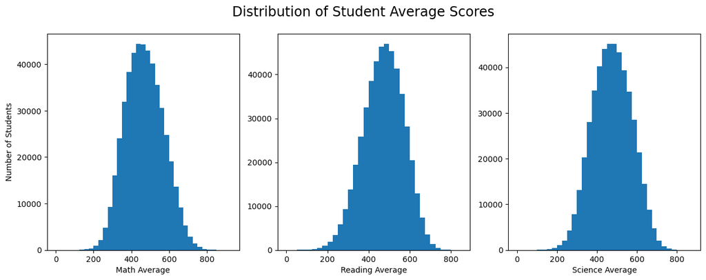

```python
# First you want to select the bin size
binsize = 25

# Then you want to pick you the size of you figure and give your subplot a title
mplt.figure(figsize = (15,5))
mplt.suptitle('Distribution of Student Average Scores', size = 'xx-large')

# Math Score Average Plot
mplt.subplot(1, 3, 1)
bins = np.arange(0, modified_pisa_data['Math Score Average'].max()+binsize, binsize)
mplt.hist(data = modified_pisa_data, x = 'Math Score Average', bins = bins)
mplt.xlabel('Math Average')
mplt.ylabel('Number of Students')

# Reading Score Average Plot
mplt.subplot(1, 3, 2)
bins = np.arange(0, modified_pisa_data['Reading Score Average'].max()+binsize, binsize)
mplt.hist(data = modified_pisa_data, x = 'Reading Score Average', bins = bins)
mplt.xlabel('Reading Average')

# Science Score Average Plot
mplt.subplot(1, 3, 3)
bins = np.arange(0, modified_pisa_data['Science Score Average'].max()+binsize, binsize)
mplt.hist(data = modified_pisa_data, x = 'Science Score Average', bins = bins)
mplt.xlabel('Science Average');
```

> From my graphs above I can see that the average score for each subject is normally distrubuted and by taking a closer look, I can see that the average score for the students ranges between 400 to 600 points for each subject.

### 2. Which country had the largest number of student participating in the test?

> - I want to look at which country had a lot of students participating in the tests, I will just pick the top 5 countries with most participation.

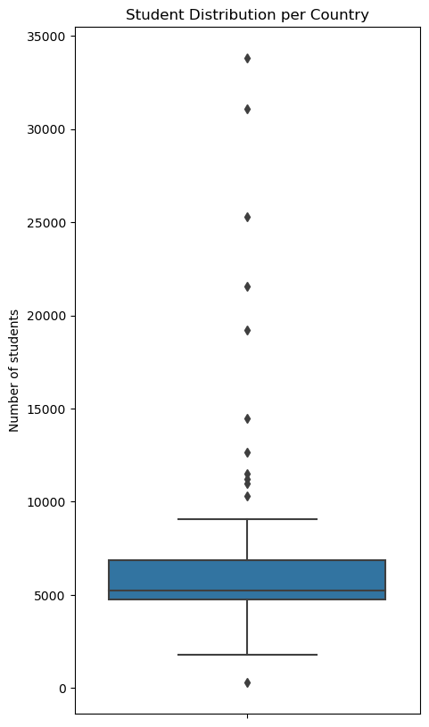

```python
# I want to plot that will give me a visual of the distribution of the students who particiated in each country.
mplt.figure(figsize=(5,10))
sb.boxplot(y = modified_pisa_data['Country Code'].value_counts(), orient = 'v')
mplt.title('Student Distribution per Country')
mplt.ylabel('Number of students', fontsize=10);
```

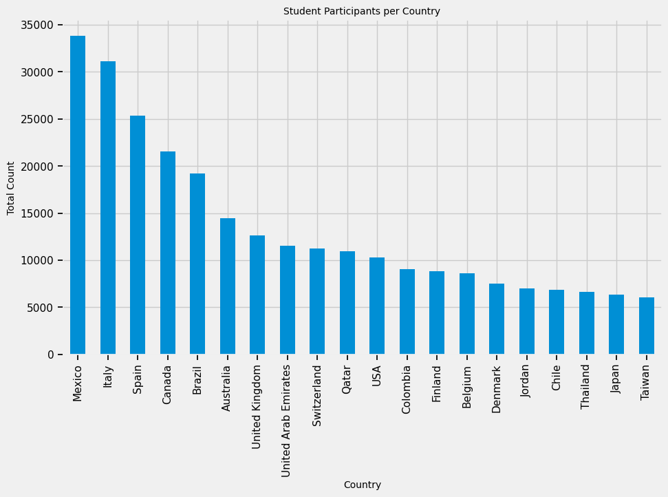

```python
# Before getting the plot I have to assign the series I want to plot
# Because there were 64 countries to look at I opted to print out the first 20 to avoid a cluster.
country_total = modified_pisa_data['Country Code'].value_counts()[:20]

# Plot the graph
bargraph_plot(country_total, 'Country', 'Total Count', 'Student Participants per Country')
```

### 3. What is the Gender Participation?

> - I want to know which gender participated more male or female. I decided to plot a donut piechart to get a visual on that.

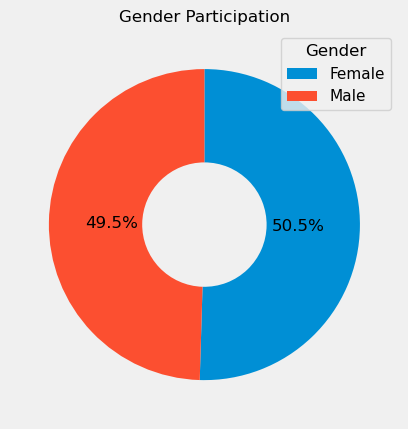

```python
# First we set up our plot with its' parameters
mplt.pie(modified_pisa_data['Gender'].value_counts(), startangle = 90, counterclock = False,
        autopct = '%1.1f%%', wedgeprops = {'width' : 0.6});

# Then we set the plot's title and legend
mplt.title("Gender Participation")
mplt.legend(['Female', 'Male'], title = 'Gender');
```

> By observing the chart we can see that the gender distribution is almost equal to each other we have a 49.5/50.5 disribution. So the number of females who participated in the test is almost equal to the number of males.

### 4. What is the Parent Work Status?

> - I just want to have a look at the parents work status for the participating students.

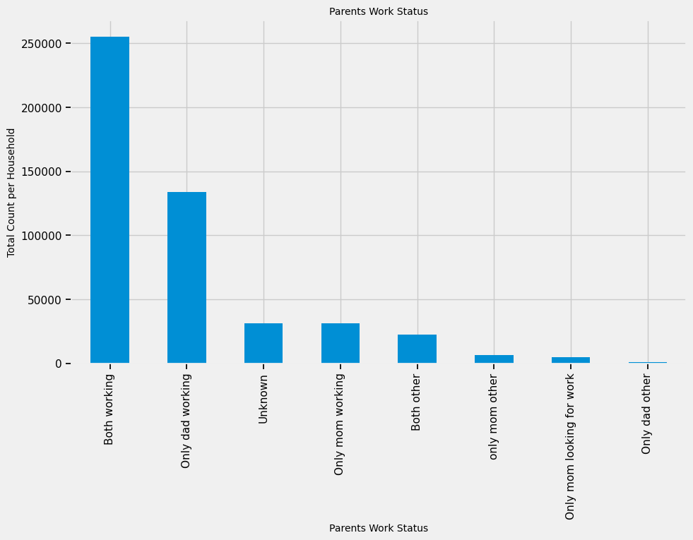

```python
# First I will have a look at the household as a whole
household_status = modified_pisa_data['Parents Work Status'].value_counts()

# Plot the graph
bargraph_plot(household_status, 'Parents Work Status', 'Total Count per Household', 'Parents Work Status')
```

> By this graph we can see that majority of the houshold has both parents working, followed by only the dad working, and the rest is very few to barely there.

### Discuss the distribution(s) of your variable(s) of interest. Were there any unusual points? Did you need to perform any transformations?

> There are few outliers in the number of students participating per country, but that is perfectly normal so no transformation need to be done.

### Of the features you investigated, were there any unusual distributions? Did you perform any operations on the data to tidy, adjust, or change the form of the data? If so, why did you do this?

> Because I cleaned my dataset prior to this visualization point I didn't face any problems so I did not have to perform any more changes on it or adjustments. My cleaning process can be seen at the top of this document on the **Cleaning the Data** section.

## Bivariate Exploration

> In this section, investigate relationships between pairs of variables in your data. Make sure the variables that you cover here have been introduced in some fashion in the previous section (univariate exploration).

### 5. Gender Participation per Country

> I want to have a look at the gender participation per country

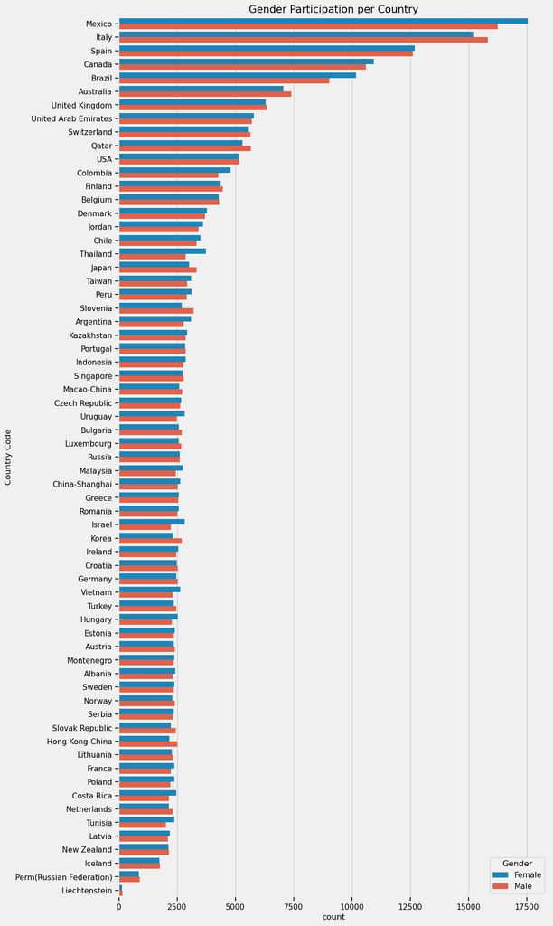

```python
# Set the style of your graph
mplt.style.use('fivethirtyeight')
sb.set_context("notebook")

# Create the value to be used
order= modified_pisa_data['Country Code'].value_counts().index

# Plot your graph
mplt.figure(figsize=[10,22])
sb.countplot(data=modified_pisa_data, y='Country Code', order=order, hue='Gender')
mplt.title('Gender Participation per Country',size=15);
```

> One thing this graph tells me is that most of the major participants per country are female. There are occassional instances where the male participant seem to be more than the females but the margin isn't that large compare to that of the females.

### 6. Subject Average per Country

> I want to see how the averages for students in each subject differs in the 65 countries that participated in the PISA Assessment.

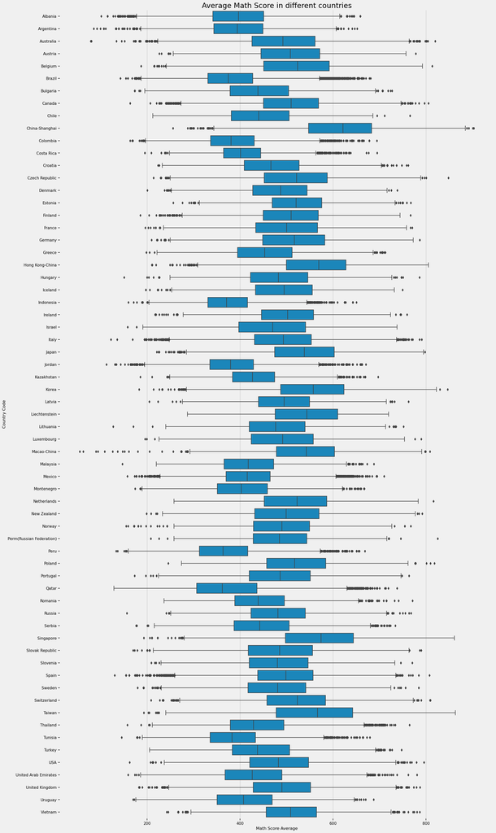

```python
# Math Score Average Plot

mplt.figure(figsize = [20, 40])
math_avg = modified_pisa_data.sort_values(by='Math Score Average')
sb.boxplot(x = modified_pisa_data['Math Score Average'], y = modified_pisa_data['Country Code'], color=sb.color_palette()[0]);
mplt.title('Average Math Score in different countries', size = 'xx-large');
```

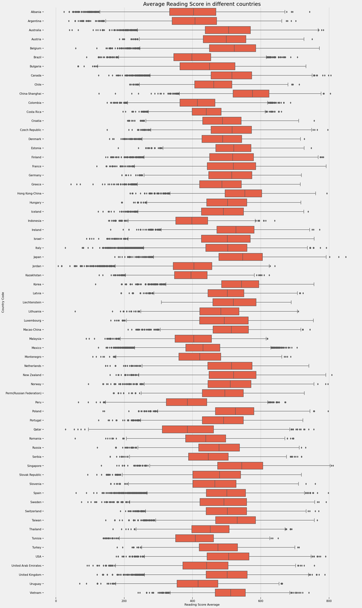

```python
# Reading Score Average Plot

mplt.figure(figsize = [20, 40])
read_avg = modified_pisa_data.sort_values(by='Reading Score Average')
sb.boxplot(x = modified_pisa_data['Reading Score Average'], y = modified_pisa_data['Country Code'], color=sb.color_palette()[1]);
mplt.title('Average Reading Score in different countries', size = 'xx-large');
```

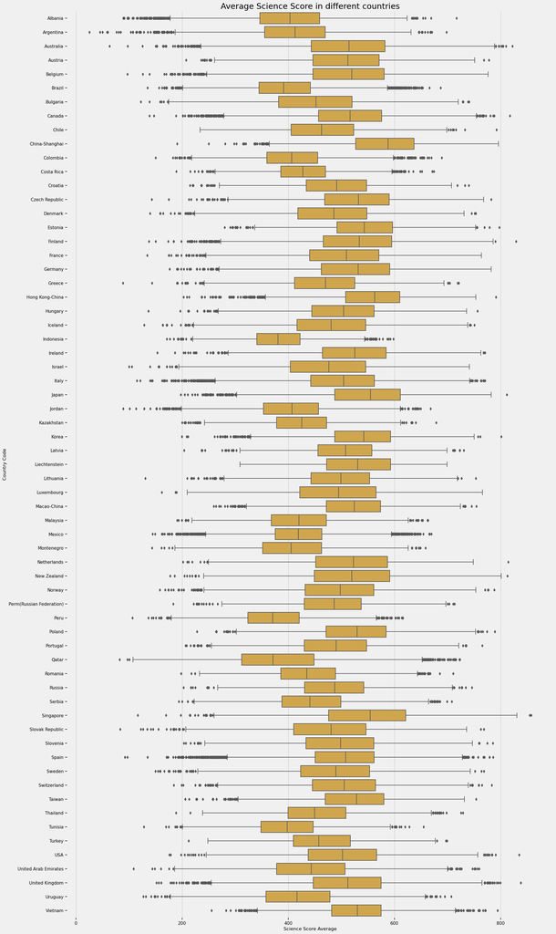

```python
# Science Score Average Plot

mplt.figure(figsize = [20, 40])
science_avg = modified_pisa_data.sort_values(by='Science Score Average')
sb.boxplot(x = modified_pisa_data['Science Score Average'], y = modified_pisa_data['Country Code'], color=sb.color_palette()[2]);
mplt.title('Average Science Score in different countries', size = 'xx-large');
```

> The graphs above allow me to see thta most of the student in all these countries are scorng in the range of 300 and 600 score points. And when you look at your outliers on both side you can see that those with low averages range between 100 and 300 points and ones with high averages range between 600 and 800 points This shows that the PISA 2012 test was developed in a proper way.

### Talk about some of the relationships you observed in this part of the investigation. How did the feature(s) of interest vary with other features in the dataset?

> In this portion I noticed how the total count of each gender in a country has an influence in that countries overall avarages per subject. That is something I didn't really think would play a big part in my analysis but now that it has piqued my interest I want to explore it further.

### Did you observe any interesting relationships between the other features (not the main feature(s) of interest)?

> Because for my dataset I only picked the columns I was interested on investigating I only had the information i wanted to look at. So I did not look at any other relationship I was not interested in

## Multivariate Exploration

> Create plots of three or more variables to investigate your data even further. Make sure that your investigations are justified, and follow from your work in the previous sections.

### 7. Subject Averages Based on Gender

> - First I just want to have a look at how both gender perform against each other.

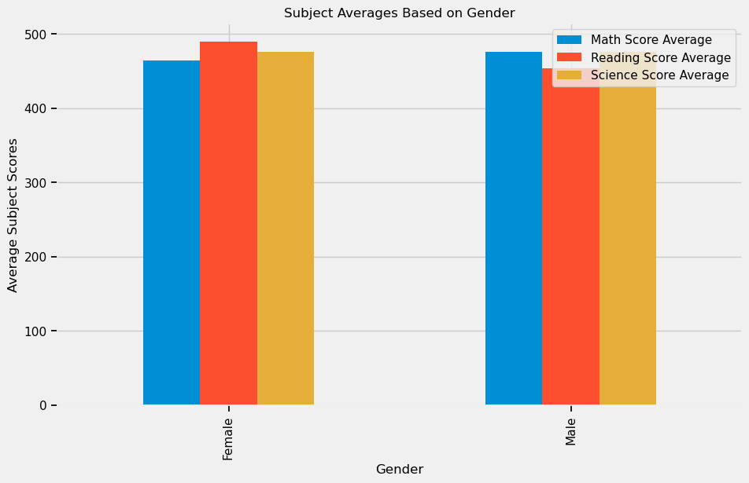

```python
avg_score = modified_pisa_data.groupby(['Gender']).mean()[['Math Score Average', 'Reading Score Average', 'Science Score Average']]
ax = avg_score.plot.bar(figsize=(10,6));
mplt.ylabel('Average Subject Scores')
mplt.title('Subject Averages Based on Gender');
```

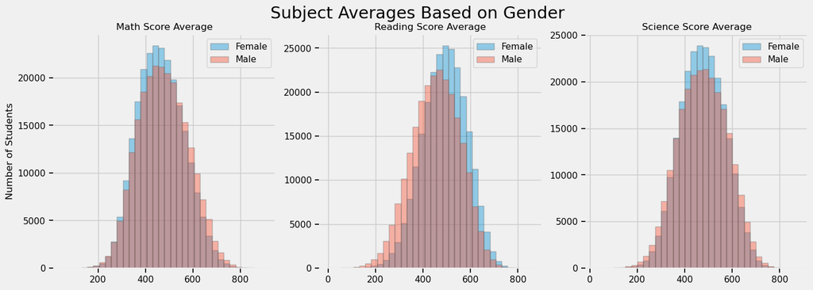

```python
# First you want to select the bin size
binsize = 25

# Then you want to pick you the size of you figure and give your subplot a title
mplt.figure(figsize = (15,5))
mplt.suptitle('Subject Averages Based on Gender', size = 'xx-large')
mplt.ylabel('Number of Students')

# Math Score Average Plot
mplt.subplot(1, 3, 1)
bins=np.arange(min(modified_pisa_data['Math Score Average']),max(modified_pisa_data['Math Score Average'])+binsize, binsize)
mplt.title('Math Score Average')
mplt.hist(data=modified_pisa_data.query('Gender=="Female"'),x='Math Score Average', ec = 'dimgrey', alpha=.4,bins=bins,label='Female')
mplt.hist(data=modified_pisa_data.query('Gender=="Male"'),x='Math Score Average', ec = 'dimgrey', alpha=.4,bins=bins, label='Male')
mplt.ylabel('Number of Students')
mplt.legend();

# Reading Score Average Plot
mplt.subplot(1, 3, 2)
bins=np.arange(min(modified_pisa_data['Reading Score Average']),max(modified_pisa_data['Reading Score Average'])+binsize, binsize)
mplt.title('Reading Score Average')
mplt.hist(data=modified_pisa_data.query('Gender=="Female"'),x='Reading Score Average', ec = 'dimgrey', alpha=.4,bins=bins,label='Female')
mplt.hist(data=modified_pisa_data.query('Gender=="Male"'),x='Reading Score Average', ec = 'dimgrey', alpha=.4,bins=bins, label='Male')
mplt.legend();

# Science Score Average Plot
mplt.subplot(1, 3, 3)
bins=np.arange(min(modified_pisa_data['Science Score Average']),max(modified_pisa_data['Science Score Average'])+binsize, binsize)
mplt.title('Science Score Average')
mplt.hist(data=modified_pisa_data.query('Gender=="Female"'),x='Science Score Average', ec = 'dimgrey', alpha=.4,bins=bins,label='Female')
mplt.hist(data=modified_pisa_data.query('Gender=="Male"'),x='Science Score Average', ec = 'dimgrey', alpha=.4,bins=bins, label='Male')
mplt.legend();
```

> This graph shows me that:
> - The females perform better in the reading than the males.
> - The males perform better than the females in maths.
> - They both perform equally in Science.

> But the differnces is not that huge so in a way we can say that they are evenly matched.

### 8. Subject Average per Parent Work Status

> I want to take a look at the outcome of the effect the parents work status has on the students average score.

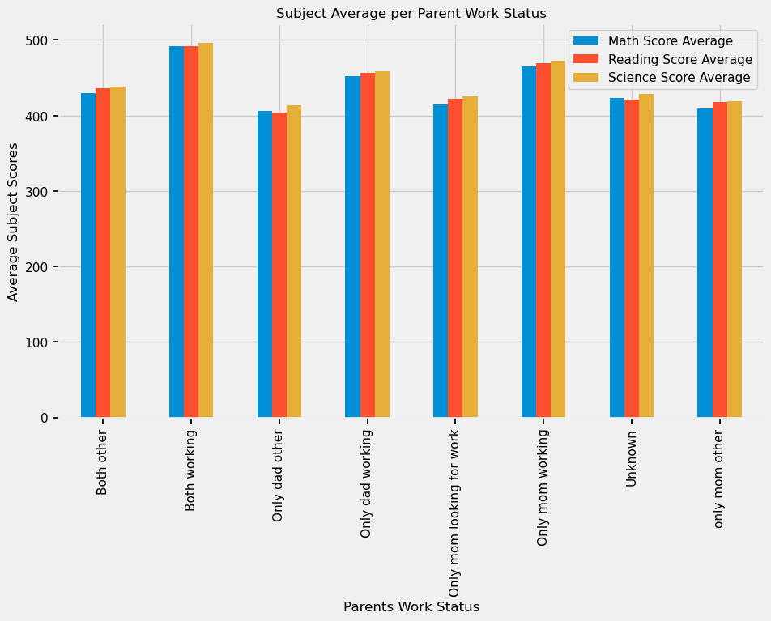

```python
avg_status = modified_pisa_data.groupby(['Parents Work Status'])['Math Score Average', 'Reading Score Average', 'Science Score Average'].mean()
ay = avg_status.plot.bar(figsize=(10,6));
mplt.ylabel('Average Subject Scores')
mplt.title('Subject Average per Parent Work Status');
```

> This graph tells us that whether both parents are working or not it doesn't really affect the overall average subject scores. But we can see that when both parents are working the average score seems to be at it highest. This could lead to further exploration but I won't dive that deep I will just say that when both parents are working they have the means to support their children on a financial level with their education.

### 9. Country With The Top Average Score

> I want to see how each country performed overall so I can have a look it the top performing contries in each subject.

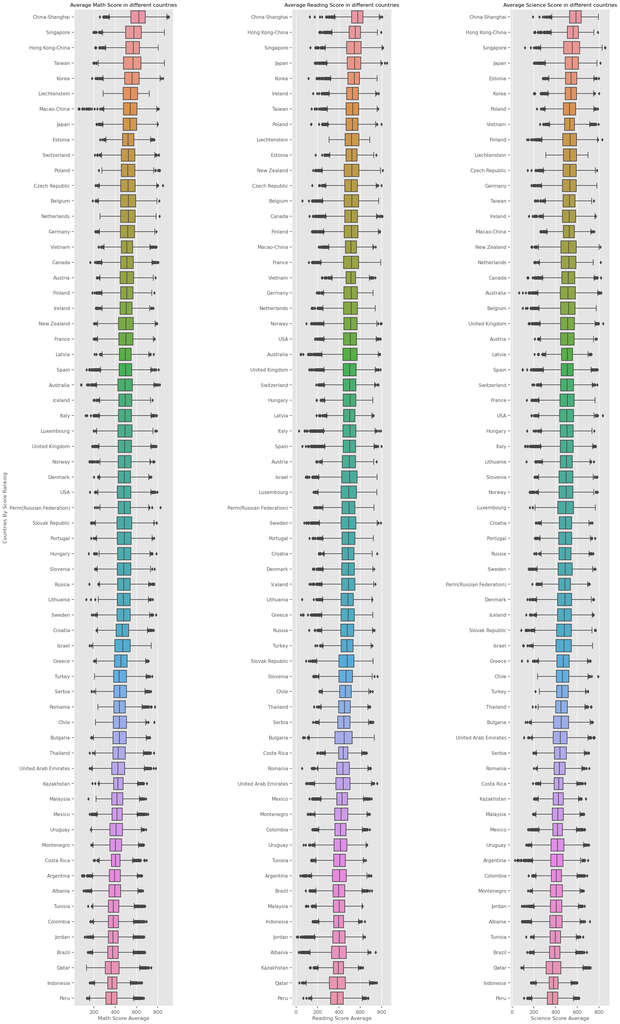

```python
# First set your order
math_order = modified_pisa_data.groupby('Country Code')['Math Score Average'].mean().sort_values(ascending = False).index
reading_order = modified_pisa_data.groupby('Country Code')['Reading Score Average'].mean().sort_values(ascending = False).index
science_order = modified_pisa_data.groupby('Country Code')['Science Score Average'].mean().sort_values(ascending = False).index

# Then you plot your subplots
mplt.style.use('ggplot')
sb.set_context("notebook")
mplt.figure(figsize = [20, 40])
# adjust the spacing between subplots, so that countries eith long names show nicely
mplt.subplots_adjust(wspace = 1.2)
mplt.title('Country With The Top Average Score', size = 'xx-large')

# Math Score Average
mplt.subplot(1, 3, 1)
sb.boxplot(x = modified_pisa_data['Math Score Average'], y = modified_pisa_data['Country Code'], order = math_order);
mplt.ylabel('Countries By Score Ranking')
mplt.title('Average Math Score in different countries');

# Reading Score Average
mplt.subplot(1, 3, 2)
sb.boxplot(x = modified_pisa_data['Reading Score Average'], y = modified_pisa_data['Country Code'], order = reading_order);
mplt.ylabel(''); # Remove the unwanted label
mplt.title('Average Reading Score in different countries');

# Science Score Average
mplt.subplot(1, 3, 3)
sb.boxplot(x = modified_pisa_data['Science Score Average'], y = modified_pisa_data['Country Code'], order = science_order);
mplt.ylabel(''); # Remove the unwanted label
mplt.title('Average Science Score in different countries');
```

> Looking at the graphs above I see that the top 3 countries with the best average per subject is:
> - China-Shanghai which has the highest average in all the subjects written, followed by Hong Kong-China and then Singapore

> The three countries with the lowest average points are:
> - Qatar, Indonesia and Peru being at the very bottom.

### 10. Birth Year of students who participated in the Survey According to Gender.

> I just want to know the birth year of each gender.

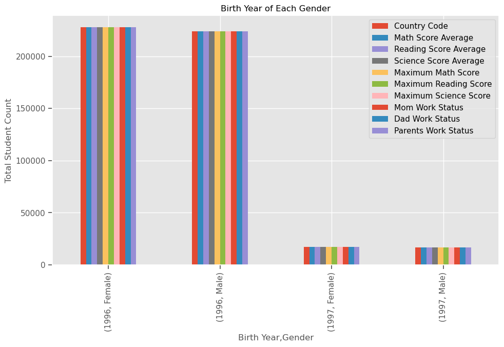

```python
year_gender = modified_pisa_data.groupby(['Birth Year', 'Gender']).count()

ax = year_gender.plot.bar(figsize=(10,6));
mplt.ylabel('Total Student Count')
mplt.title('Birth Year of Each Gender');
```

> This really didn't give me an insight on much besides on the birth year of each gender and we saw that majority of the particpants were born in 1996 and the females are more than the males. By looking at this we can see that in the participation of male and female born in 1997 are equal.

### 11. What is the correlation between the three subjects?

> I want to see how each subject relate to each other.

```
<function matplotlib.pyplot.show(close=None, block=None)>
```

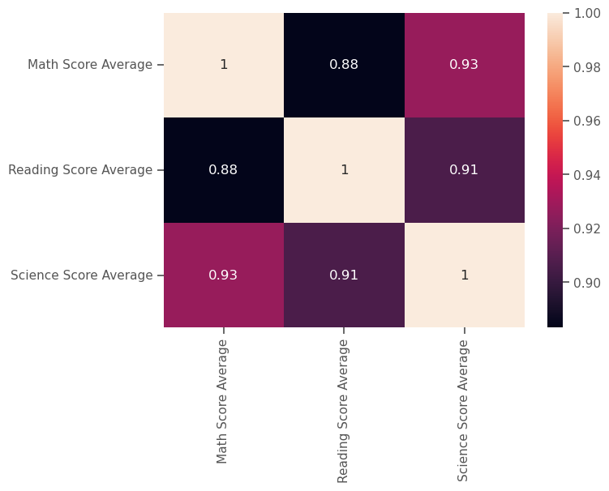

```python
corr_avg = pd.DataFrame(modified_pisa_data, columns = ['Math Score Average', 'Reading Score Average', 'Science Score Average'])
sub_matrix = corr_avg.corr()
sb.heatmap(sub_matrix, annot = True)
mplt.show
```

> As expected there is a solid, strong and positive correlation between any pair of the three subjects to the scores of the three subjects. Upon further inspection I see that even though they all have a strong positive correlation, the correlation between math and reading is the lowest and vice-versa. This could be because math isn't dependent on reading and vice-versa where as they both have an effect on the outcome of science. Because to be good in science you need to be good in both math and reading.

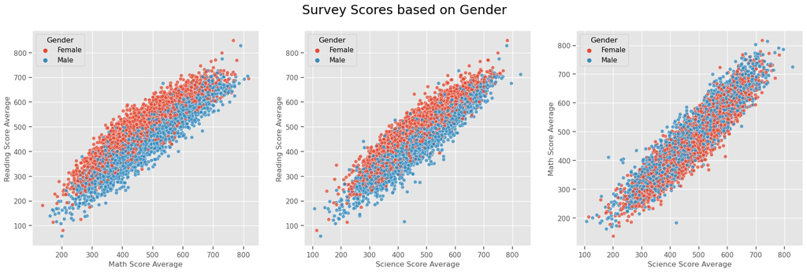

```python
# I want to take a look at the pairwise correlations that exists between features in the dataset.

# I want to plot a sample of 10000 students so that plots doesn't take forever to load.
samples = np.random.choice(modified_pisa_data.shape[0], 10000, replace=False)
students_samp = modified_pisa_data.loc[samples, :]

fig = mplt.figure(figsize=[20, 6])
mplt.suptitle('Survey Scores based on Gender', size='xx-large')

mplt.subplot(1, 3, 1)
sb.scatterplot(data=students_samp,
               x='Math Score Average',
               y='Reading Score Average',
               hue='Gender',
               alpha=0.75)

mplt.subplot(1, 3, 2)
sb.scatterplot(data=students_samp,
               x='Science Score Average',
               y='Reading Score Average',
               hue='Gender',
               alpha=0.75)

mplt.subplot(1, 3, 3)
sb.scatterplot(data=students_samp,
               x='Science Score Average',
               y='Math Score Average',
               hue='Gender',
               alpha=0.75)
```

### Were there any interesting or surprising interactions between features?

> I was suprised that China-Shanghai had the highest average in all the subjects written, followed by Hong Kong-China and then Singapore and that the top 5 countries with the highest student participation didn't really score the highest average. One would think that with the large number of student participants the average would seem higher. Not here though other factors such as gender played a part.

## Conclusions

> When I started with my exploration I was mainly interested in the factors that contributes to the total averages of **Math, Reading and Science**.

> I was majorly interested on how the **Parents Work Status** would affect the score averages for the students, so to say in the least I was a bit dissapointed that I didn't get the outcome I was looking for.

> Even though **Birth Year** was one of my factors of interest, I saw that I would need other factors which I did not include in my dataset. So this also turned out to not give me any promising outcome because there was not much information I could get from it.

> The two factors that gave me the most results were **Gender and Country Code** suprisingly enough they were the two factors I thought would not contribute much to the overall averages.

> I learned that more females participated in the survey than males. Since the females performed better than the males when it came to **Reading** any country that had more female participants would have a better average in that. The male participants performed better than the females when it came to **Math** and so any country that had more male participants would have a better average in that. They performed evenly equal when it came to **Science**, so the overall average depended on the number of gender participation when it came to that. This is because science is a mixture of both reading and maths so if you have more females the average favors them and vice-versa.

### Limitations

> - This dataset is very large and requires a PC with a very large RAM in order to open it directly and not as a compressed zip folder.
> - Because of the file size, I was limited to only pick a few columns to work with and this caused my exploration to only focus on what I picked.

> Given an oppurtunity I would explore every factors that I could because this dataset has a lot to explore but because of my limitations could only explore a few. The good thing is this test is written every year by different candidates so there's always going to be something new to look forward to if you want to work with the PISA dataset.

## Reference

> I mainly used these two websites to seach for assisstance that I needed.
> - www.stackoverflow.com
> - www.google.com